# Inference Model Calibration Testing

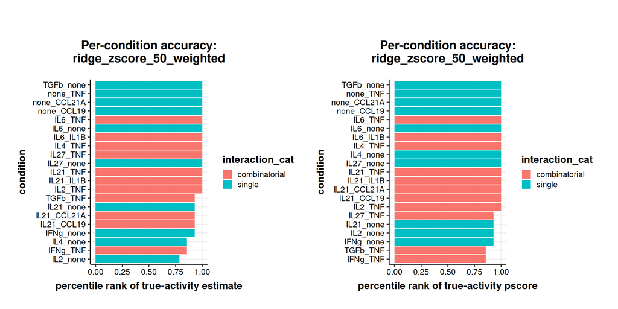

```r
ggsave("../../analysis_outs/plots/inference_model_calibration/model_testing_estimate_percentile_boxplots_SIG14.pdf")
# per-ligand/pair breakdown for the selected model, ordered so the
# worst-recovered conditions (lowest percentile) surface first
percentile_by_condition <- activity_out %>%
  filter(model == "ridge_zscore_50_weighted", category == "true_activity") %>%
  select(term, target_activity, interaction_cat, estimate, estimate_percentile, pscore_percentile, category) %>%
  arrange(estimate_percentile)

p1 <- percentile_by_condition %>%
  ggplot(aes(x = reorder(term, estimate_percentile), y = estimate_percentile, fill = interaction_cat)) +
  geom_col() +
  coord_flip() +
  labs(x = "condition", y = "percentile rank of true-activity estimate",
       title = "Per-condition accuracy:\nridge_zscore_50_weighted")

p2 <- percentile_by_condition %>%
  ggplot(aes(x = reorder(term, pscore_percentile), y = pscore_percentile, fill = interaction_cat)) +
  geom_col() +
  coord_flip() +
  labs(x = "condition", y = "percentile rank of true-activity pscore",
       title = "Per-condition accuracy:\nridge_zscore_50_weighted")

p1+p2
```

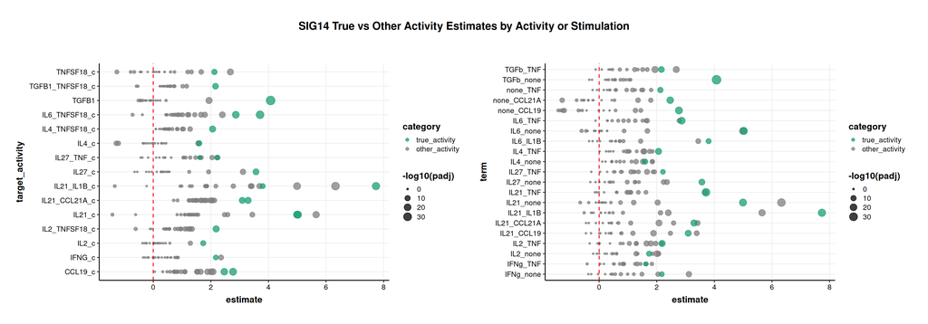

```r
ggsave("../../analysis_outs/plots/inference_model_calibration/model_testing_estimate_percentile_bar_SIG14.pdf")
# pull out stims where corrrect estimate is not 1
missestimates <- percentile_by_condition %>%
  filter(estimate_percentile < 1) %>%
  pull(target_activity)

p1 <- activity_out %>%
  filter(model == "ridge_zscore_50_weighted") %>%
  filter(!is.na(category)) %>%
  arrange(category == "true_activity") %>%
  ggplot(aes(y = target_activity, x = estimate, color = category)) +
  scale_color_manual(values = c("#1B9E77FF","grey50"),
                     breaks = c("true_activity","other_activity")) +
  geom_point(aes(size = -log10(padj)), alpha = 0.75) +
  geom_vline(xintercept = 0, lty = 2, color = "red") +
  theme(aspect.ratio = 0.75)

p2 <- activity_out %>%
  filter(model == "ridge_zscore_50_weighted") %>%
  filter(!is.na(category)) %>%
  arrange(category == "true_activity") %>%
  ggplot(aes(y = term, x = estimate, color = category)) +
  scale_color_manual(values = c("#1B9E77FF","grey50"),
                     breaks = c("true_activity","other_activity")) +
  geom_point(aes(size = -log10(padj)), alpha = 0.75) +
  geom_vline(xintercept = 0, lty = 2, color = "red") +
  theme(aspect.ratio = 0.75)

p1+p2+plot_annotation("SIG14 True vs Other Activity Estimates by Activity or Stimulation")
```

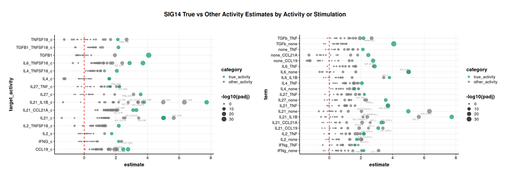

```r
ggsave("../../analysis_outs/plots/inference_model_calibration/model_testing_estimates_by_stimulation_scatter_SIG14.pdf")
p1 <- activity_out %>%
  filter(model == "ridge_zscore_50_weighted") %>%
  filter(!is.na(category)) %>%
  mutate(label = ifelse(estimate > 2 & category == "other_activity", term, "")) %>%
  arrange(category == "true_activity") %>%
  ggplot(aes(y = target_activity, x = estimate, color = category)) +
  scale_color_manual(values = c("#1B9E77FF","grey50"),
                     breaks = c("true_activity","other_activity")) +
  geom_point(aes(size = -log10(padj)), alpha = 0.75) +
  geom_vline(xintercept = 0, lty = 2, color = "red") +
  geom_text_repel(aes(label = label), size = 2) +
  theme(aspect.ratio = 0.75)

p2 <- activity_out %>%
  filter(model == "ridge_zscore_50_weighted") %>%
  filter(!is.na(category)) %>%
  mutate(label = ifelse(estimate > 2 & category == "other_activity", target_activity, "")) %>%
  arrange(category == "true_activity") %>%
  ggplot(aes(y = term, x = estimate, color = category)) +
  scale_color_manual(values = c("#1B9E77FF","grey50"),
                     breaks = c("true_activity","other_activity")) +
  geom_point(aes(size = -log10(padj)), alpha = 0.75) +
  geom_vline(xintercept = 0, lty = 2, color = "red") +
  geom_text_repel(aes(label = label), size = 2) +
  theme(aspect.ratio = 0.75)

p1+p2+plot_annotation("SIG14 True vs Other Activity Estimates by Activity or Stimulation")
```

```r
ggsave("../../analysis_outs/plots/inference_model_calibration/model_testing_estimates_by_stimulation_scatter_labeled_SIG14.pdf")
```

# SIG26 Calibration Results

```r
activity_combined <- read_csv('../../analysis_outs/inference_model_calibration/activity_combined_SIG26-6h.csv')
```

```r
# define ligands in experiments and associated signaling activities in model
mapping_tibble <- tibble(
  stim = c(
    'IFNG_TNF', 'IFNG_none',
    'IL21_TNF', 'IL21_none', 'IL27_TNF', 'IL27_none', 'IL2_TNF',
    'IL2_none', 'IL4_TNF', 'IL4_none',
    'IL6_TNF', 'IL6_none', 'TGFB_TNF', 'TGFB_none', 'none_TNF',
    'IL4_IL21', 'IL27_IL21',
    'TGFB_IL4', 'TGFB_IL2'
  ),
  activity = c(
    'IL27_TNF_c', 'IL27_c',
    'IL6_TNFSF18_c', 'IL21_c', 'IL27_TNF_c', 'IL27_c', 'IL2_TNFSF18_c',
    'IL2_c', 'IL4_TNFSF18_c', 'IL4_c',
    'IL6_TNFSF18_c', 'IL21_c', 'TGFB1_TNFSF18_c', 'TGFB1', 'TNFSF18_c',
    'IL4_IL21_c', 'IL27_IL21_c',
    'TGFB1_IL4_c', 'TGFB1_IL4_c'
  )
)
```

```r
# for each activity and model, perform linear modeling to quantify activity differences
activity_out <- tibble()
for(m in unique(activity_combined$model)) {
  df <- activity_combined %>%
    filter(model == m) %>%
    separate_wider_delim(sample, "_", names = c("ligand1", "ligand2", "donor","well")) %>%
    mutate(condition = factor(paste0(ligand1, "_", ligand2))) %>%
    mutate(condition = relevel(condition, ref = "none_none"))
  for(y_var in unique(mapping_tibble$activity)) {
    # define pos and negative conditions
    pos_ligands <- mapping_tibble %>%
      filter(activity == y_var) %>%
      pull(stim)
    neg_ligands <- mapping_tibble %>%
      filter(activity != y_var) %>%
      pull(stim)
    # run lm
    out <- lm(as.formula(paste0(y_var, '~ condition')), df) %>%
      broom::tidy() %>%
      filter(grepl("condition", term)) %>%
      mutate(term = gsub("condition", "", term)) %>%
      mutate(
        category = case_when(
          term %in% pos_ligands ~ "true_activity",
          term %in% neg_ligands ~ "other_activity"
        ),
        model = m,
        target_activity = y_var
      ) %>%
      mutate(padj = p.adjust(p.value))

    activity_out <- bind_rows(activity_out, out)
  }
}
activity_out <- activity_out %>%
  mutate(interaction_cat = ifelse(grepl("none",term),"single","combinatorial"),
         pscore = -log10(padj))
```

## ROC analysis

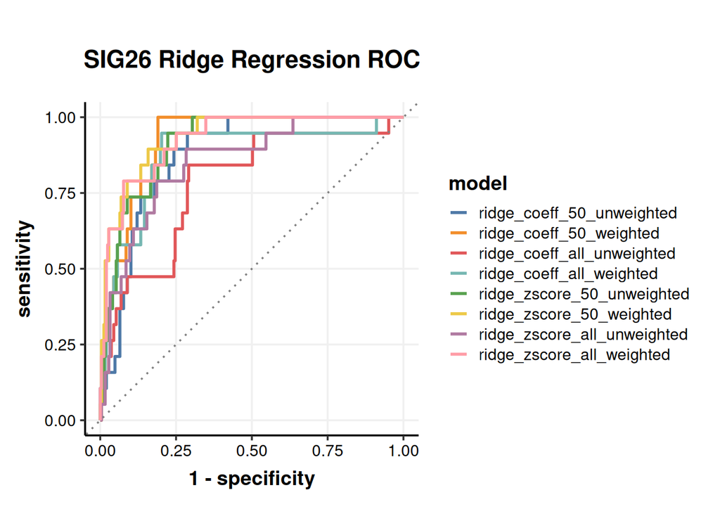

```r
# Calculate and visualize ROC curves by model
activity_out %>%
  filter(!is.na(category)) %>%
  mutate(category = factor(category, levels = c("true_activity", "other_activity"))) %>%
  group_by(model) %>%
  roc_curve(category, estimate) %>%
  ggplot(aes(x = 1 - specificity, y = sensitivity, color = model)) +
  geom_path(linewidth = 1) +
  geom_abline(lty = 3, color = "grey50") +
  scale_color_manual(values = tab10_colors) +
  coord_equal() +
  ggtitle("SIG26 Ridge Regression ROC")
```

```r
# Calculate AUC values for each model
activity_out %>%
  filter(!is.na(category)) %>%
  mutate(category = factor(category, levels = c("true_activity", "other_activity"))) %>%
  group_by(model) %>%
  roc_auc(category, estimate)
```

```
## # A tibble: 8 × 4
##   model                       .metric .estimator .estimate
##   <chr>                       <chr>   <chr>          <dbl>
## 1 ridge_coeff_50_unweighted   roc_auc binary         0.876
## 2 ridge_coeff_50_weighted     roc_auc binary         0.922
## 3 ridge_coeff_all_unweighted  roc_auc binary         0.780
## 4 ridge_coeff_all_weighted    roc_auc binary         0.875
## 5 ridge_zscore_50_unweighted  roc_auc binary         0.914
## 6 ridge_zscore_50_weighted    roc_auc binary         0.935
## 7 ridge_zscore_all_unweighted roc_auc binary         0.852
## 8 ridge_zscore_all_weighted   roc_auc binary         0.927
```

```r
ggsave("../../analysis_outs/plots/inference_model_calibration/model_testing_ROC_SIG26.pdf")
# retain SIG26 results for the joint SIG14 + SIG26 ROC comparison below
activity_out_SIG26 <- activity_out
```

[output not shown]

## Per-condition accuracy

The ROC/AUC above pools every ligand/pair together, which can hide conditions the model fails on. Instead, for each `model x stimulation` group, rank every predicted activity estimate and ask where the true-activity condition falls: `percent_rank()` puts the highest estimate at 1, so a true-activity row near 1 means the model correctly picked that condition out from all the others tested for that activity. We also compare the raw estimate and significance of enrichment for true and false activities.

```r
activity_out <- activity_out %>%
  group_by(model, term) %>%
  mutate(estimate_percentile = percent_rank(estimate),
         pscore_percentile = percent_rank(-log10(padj))) %>%
  ungroup()
```

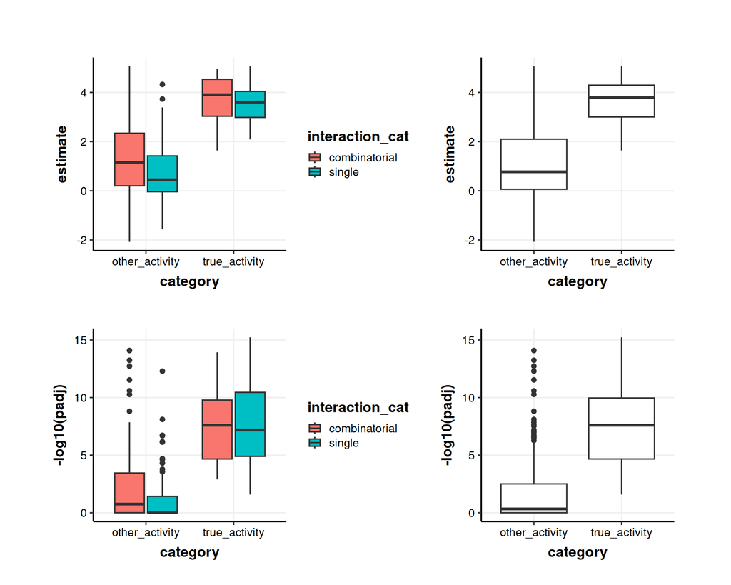

```r
p1 <- activity_out %>%
  filter(model == "ridge_zscore_50_weighted") %>%
  filter(!is.na(category)) %>%
  ggplot(aes(x = category, y = estimate)) +
  geom_boxplot(aes(fill = interaction_cat)) +
  theme(aspect.ratio=1)

p2 <- activity_out %>%
  filter(model == "ridge_zscore_50_weighted") %>%
  filter(!is.na(category)) %>%
  ggplot(aes(x = category, y = estimate)) +
  geom_boxplot() +
  theme(aspect.ratio=1)

p3 <- activity_out %>%
  filter(model == "ridge_zscore_50_weighted") %>%
  filter(!is.na(category)) %>%
  ggplot(aes(x = category, y = -log10(padj))) +
  geom_boxplot(aes(fill = interaction_cat)) +
  theme(aspect.ratio=1)

p4 <- activity_out %>%
  filter(model == "ridge_zscore_50_weighted") %>%
  filter(!is.na(category)) %>%
  ggplot(aes(x = category,  y = -log10(padj))) +
  geom_boxplot() +
  theme(aspect.ratio=1)

p1+p2+p3+p4+plot_layout(ncol = 2)
```

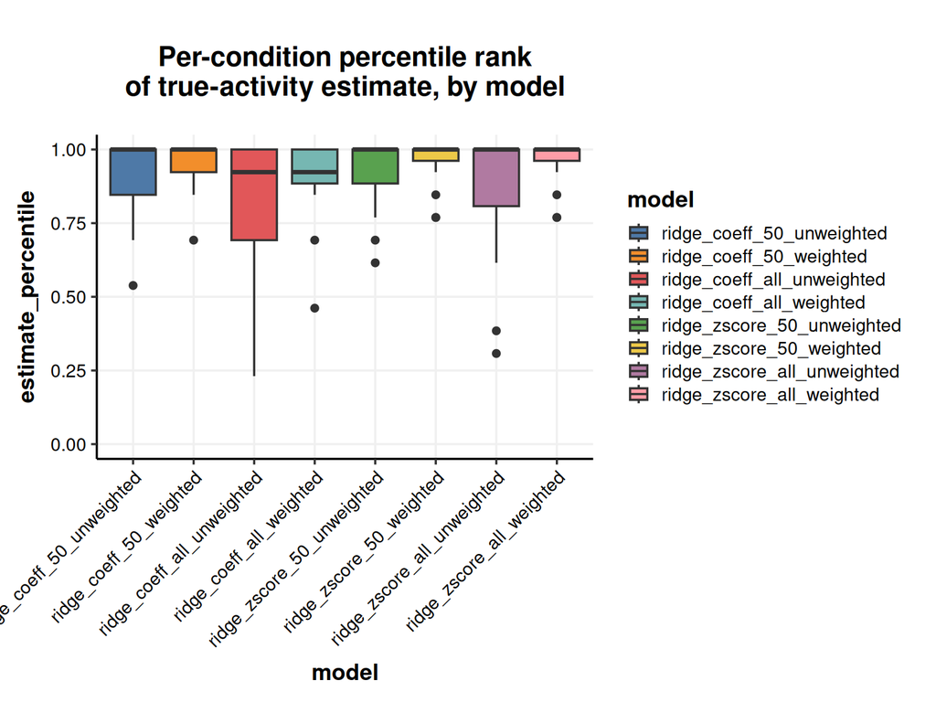

```r
ggsave("../../analysis_outs/plots/inference_model_calibration/model_testing_estimate_boxplots_SIG26.pdf")
# do any models produce more per-ligand/pair outliers than others?
activity_out %>%
  filter(category == "true_activity") %>%
  ggplot(aes(x = model, y = estimate_percentile)) +
  geom_boxplot(aes(fill = model)) +
  ylim(0,1) +
  scale_fill_manual(values = tab10_colors) +
  theme(axis.text.x = element_text(angle = 45, hjust = 1)) +
  ggtitle("Per-condition percentile rank\nof true-activity estimate, by model")
```

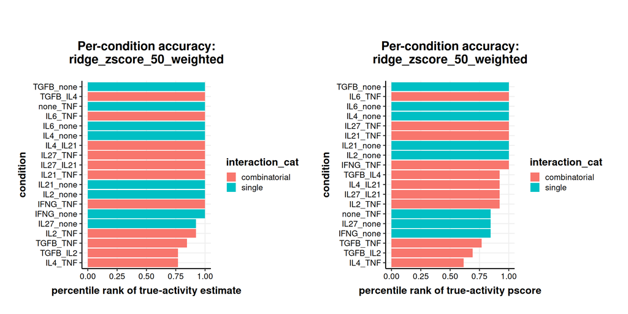

```r
ggsave("../../analysis_outs/plots/inference_model_calibration/model_testing_estimate_percentile_boxplots_SIG26.pdf")
# per-ligand/pair breakdown for the selected model, ordered so the
# worst-recovered conditions (lowest percentile) surface first
percentile_by_condition <- activity_out %>%
  filter(model == "ridge_zscore_50_weighted", category == "true_activity") %>%
  select(term, target_activity, interaction_cat, estimate, estimate_percentile, pscore_percentile, category) %>%
  arrange(estimate_percentile)

p1 <- percentile_by_condition %>%
  ggplot(aes(x = reorder(term, estimate_percentile), y = estimate_percentile, fill = interaction_cat)) +
  geom_col() +
  coord_flip() +
  labs(x = "condition", y = "percentile rank of true-activity estimate",
       title = "Per-condition accuracy:\nridge_zscore_50_weighted")

p2 <- percentile_by_condition %>%
  ggplot(aes(x = reorder(term, pscore_percentile), y = pscore_percentile, fill = interaction_cat)) +
  geom_col() +
  coord_flip() +
  labs(x = "condition", y = "percentile rank of true-activity pscore",
       title = "Per-condition accuracy:\nridge_zscore_50_weighted")

p1+p2
```

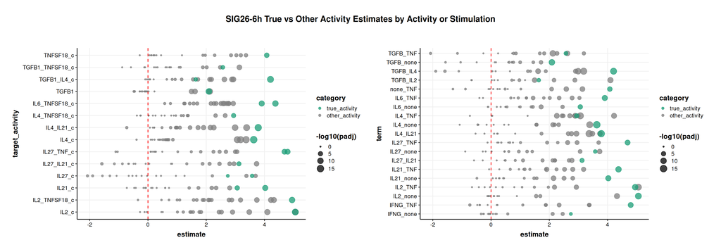

```r
ggsave("../../analysis_outs/plots/inference_model_calibration/model_testing_estimate_percentile_bar_SIG26.pdf")
p1 <- activity_out %>%
  filter(model == "ridge_zscore_50_weighted") %>%
  filter(!is.na(category)) %>%
  arrange(category == "true_activity") %>%
  ggplot(aes(y = target_activity, x = estimate, color = category)) +
  scale_color_manual(values = c("#1B9E77FF","grey50"),
                     breaks = c("true_activity","other_activity")) +
  geom_point(aes(size = -log10(padj)), alpha = 0.75) +
  geom_vline(xintercept = 0, lty = 2, color = "red") +
  theme(aspect.ratio = 0.75)

p2 <- activity_out %>%
  filter(model == "ridge_zscore_50_weighted") %>%
  filter(!is.na(category)) %>%
  arrange(category == "true_activity") %>%
  ggplot(aes(y = term, x = estimate, color = category)) +
  scale_color_manual(values = c("#1B9E77FF","grey50"),
                     breaks = c("true_activity","other_activity")) +
  geom_point(aes(size = -log10(padj)), alpha = 0.75) +
  geom_vline(xintercept = 0, lty = 2, color = "red") +
  theme(aspect.ratio = 0.75)

p1+p2+plot_annotation("SIG26-6h True vs Other Activity Estimates by Activity or Stimulation")
```

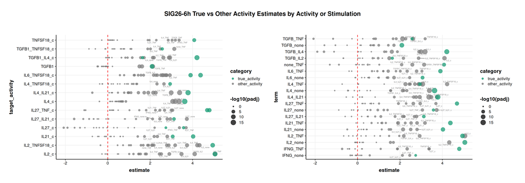

```r
ggsave("../../analysis_outs/plots/inference_model_calibration/model_testing_estimates_by_stimulation_scatter_SIG26.pdf")
p1 <- activity_out %>%
  filter(model == "ridge_zscore_50_weighted") %>%
  filter(!is.na(category)) %>%
  mutate(label = ifelse(estimate > 2 & category == "other_activity", term, "")) %>%
  arrange(category == "true_activity") %>%
  ggplot(aes(y = target_activity, x = estimate, color = category)) +
  scale_color_manual(values = c("#1B9E77FF","grey50"),
                     breaks = c("true_activity","other_activity")) +
  geom_point(aes(size = -log10(padj)), alpha = 0.75) +
  geom_vline(xintercept = 0, lty = 2, color = "red") +
  geom_text_repel(aes(label = label), size = 2) +
  theme(aspect.ratio = 0.75)

p2 <- activity_out %>%
  filter(model == "ridge_zscore_50_weighted") %>%
  filter(!is.na(category)) %>%
  mutate(label = ifelse(estimate > 2 & category == "other_activity", target_activity, "")) %>%
  arrange(category == "true_activity") %>%
  ggplot(aes(y = term, x = estimate, color = category)) +
  scale_color_manual(values = c("#1B9E77FF","grey50"),
                     breaks = c("true_activity","other_activity")) +
  geom_point(aes(size = -log10(padj)), alpha = 0.75) +
  geom_vline(xintercept = 0, lty = 2, color = "red") +
  geom_text_repel(aes(label = label), size = 2) +
  theme(aspect.ratio = 0.75)

p1+p2+plot_annotation("SIG26-6h True vs Other Activity Estimates by Activity or Stimulation")
```

```r
ggsave("../../analysis_outs/plots/inference_model_calibration/model_testing_estimates_by_stimulation_scatter_labeled_SIG26.pdf")
```